# TMC_cox_ph_model_analysis

## COX PH MODEL ANALYSIS

#### DATA Preparation Again-

```python
# Import the required libraries & modules
import pandas as pd
import numpy as np
import matplotlib.pyplot as plt
import seaborn as sns
%matplotlib inline
```

```python
gbc_patients = pd.read_excel("GBC.xlsx")
```

```python
gbc_patients.head()
```

|  | MR_NO | Comorbidities_final | Thyroidism | Diabetes | HTN | Family_cancer_history | ECOG_final | Gall_stone_final | Pathology | Tumour_grade_final | ... | ALT - SGPT | ALK PHOS [ALP] | GAMMA GT | ALBUMIN | CREATININE_from_UnC_test | UREA_from_UnC_test | ESTIMATED AVERAGE GLUCOSE (eAG) | HbA1c | CREATININE_from_CREATININE_test | Diabetes_final |
| --- | --- | --- | --- | --- | --- | --- | --- | --- | --- | --- | --- | --- | --- | --- | --- | --- | --- | --- | --- | --- | --- |
| 0 | MR/17/000051 | NaN | No | No | Yes | No | 1 | Yes | Adenocarcinoma | Grade 3 | ... | 28.0 | 147.0 | 21.0 | 4.7 | NaN | NaN | 137.0 | 6.4 | 0.64 | Yes |
| 1 | MR/17/000165 | NaN | No | No | No | No | Not known | No | Adenocarcinoma | Grade X | ... | 27.0 | 83.0 | 76.0 | 3.4 | NaN | NaN | NaN | NaN | NaN | No |
| 2 | MR/17/000504 | NaN | Hypothyroidism | Yes | Yes | Not known | Not known | Not known | Adenocarcinoma | Grade 3 | ... | NaN | NaN | NaN | NaN | NaN | NaN | NaN | NaN | NaN | Yes |
| 3 | MR/17/000600 | NaN | No | No | Yes | No | 1 | No | Adenocarcinoma | Grade X | ... | 98.0 | 481.0 | 83.0 | 4.1 | NaN | NaN | 117.0 | 5.7 | 1.08 | Yes |
| 4 | MR/17/000665 | NaN | No | No | No | No | 1 | Not known | Adenocarcinoma | Grade X | ... | 78.0 | 206.0 | 481.0 | 3.2 | NaN | NaN | NaN | NaN | 0.60 | No |

5 rows × 50 columns

#### Filtered Data - Used for analysis

```python
filtered_data = gbc_patients.dropna(subset=[ 'Status','Date_event', 'Date_diagnosis'])
filtered_data.shape
```

```
(426, 50)
```

```python
filtered_data["Status"].value_counts()
```

```
Dead    425
No        1
Name: Status, dtype: int64
```

```python
# Calculate the difference of Date_event and Date_diagnosis in months
filtered_data['Time_overall_study'] = ((filtered_data['Date_event'] - filtered_data['Date_diagnosis']) / np.timedelta64(1, 'M')).astype(float)

filtered_data.head()
```

|  | MR_NO | Comorbidities_final | Thyroidism | Diabetes | HTN | Family_cancer_history | ECOG_final | Gall_stone_final | Pathology | Tumour_grade_final | ... | ALK PHOS [ALP] | GAMMA GT | ALBUMIN | CREATININE_from_UnC_test | UREA_from_UnC_test | ESTIMATED AVERAGE GLUCOSE (eAG) | HbA1c | CREATININE_from_CREATININE_test | Diabetes_final | Time_overall_study |
| --- | --- | --- | --- | --- | --- | --- | --- | --- | --- | --- | --- | --- | --- | --- | --- | --- | --- | --- | --- | --- | --- |
| 0 | MR/17/000051 | NaN | No | No | Yes | No | 1 | Yes | Adenocarcinoma | Grade 3 | ... | 147.0 | 21.0 | 4.7 | NaN | NaN | 137.0 | 6.4 | 0.64 | Yes | 24.246904 |
| 4 | MR/17/000665 | NaN | No | No | No | No | 1 | Not known | Adenocarcinoma | Grade X | ... | 206.0 | 481.0 | 3.2 | NaN | NaN | NaN | NaN | 0.60 | No | 11.860613 |
| 5 | MR/17/000682 | NaN | No | No | Yes | No | 2 | Yes | Adenocarcinoma | Grade X | ... | NaN | NaN | NaN | NaN | NaN | NaN | NaN | 0.61 | No | 17.248814 |
| 7 | MR/17/001311 | Heart disease | No | Yes | Yes | Not known | 1 | Yes | MiNEN | Grade 2 | ... | 108.0 | 21.0 | 4.6 | NaN | NaN | NaN | NaN | NaN | Yes | 23.852646 |
| 8 | MR/17/001536 | NaN | Hypothyroidism | Not known | Yes | Not known | Not known | Yes | Adenocarcinoma | Grade X | ... | 492.0 | 209.0 | 2.6 | NaN | NaN | NaN | NaN | NaN | Not known | 12.846260 |

5 rows × 51 columns

```python
# Replace 'column_name' with the actual name of your column
row = filtered_data[filtered_data['Time_overall_study'] == -8.01659171646235]

print(row["Status"])
print(row["Date_event"])
print(row["Date_diagnosis"])
```

```
657    Dead
Name: Status, dtype: object
657   2019-02-23
Name: Date_event, dtype: datetime64[ns]
657   2019-10-25
Name: Date_diagnosis, dtype: datetime64[ns]
```

```python
#Time_overall_study feature
value_to_delete = -8.01659171646235

# Delete the row with the specified value
filtered_data = filtered_data[filtered_data['Time_overall_study'] != value_to_delete]

filtered_data.shape
```

```
(425, 51)
```

#### Filtered data have 425 observations and 51 features

#### Wrong entry of data, deleted.

```python
# Mapping of values to be replaced
status_mapping = {'Dead': 1, 'No': 0}

# Replace values in the "Status" column
filtered_data['Status'] = filtered_data['Status'].replace(status_mapping)
```

```python
filtered_data['Status'].value_counts()
```

```
1    424
0      1
Name: Status, dtype: int64
```

```python
df = filtered_data.copy()
```

```python
###########################################################
```

## Cox PH Model Analysis

```python
df.shape
```

```
(425, 51)
```

```python
df['Status'].value_counts()
```

```
1    424
0      1
Name: Status, dtype: int64
```

```python
df.columns
```

```
Index(['MR_NO', 'Comorbidities_final', 'Thyroidism', 'Diabetes', 'HTN',
       'Family_cancer_history', 'ECOG_final', 'Gall_stone_final', 'Pathology',
       'Tumour_grade_final', 'Cancer_presentation_final', 'Tumour_stage_final',
       'TNM_classification', 'Metastasis_final', 'Site_metastasis',
       'Mets_site_final', 'Cholecystectomy_TMC', 'Outside_cholecystectomy',
       'Surgery_final', 'Treatment_final', 'Treatment_clean', 'Treatment',
       'Status', 'Date_event', 'Date_diagnosis', 'AGE', 'GENDER', 'COUNTRY',
       'STATE_NAME', 'CITY_NAME', 'PINCODE', 'First_Visit_Date', 'HEIGHT',
       'WEIGHT', 'BSA_DETAILS', 'BMI_DETAILS', 'BILIRUBIN CONJUGATED',
       'BILIRUBIN UNCONJUGATED', 'BILIRUBIN TOTAL', 'AST - SGOT', 'ALT - SGPT',
       'ALK PHOS [ALP]', 'GAMMA GT', 'ALBUMIN', 'CREATININE_from_UnC_test',
       'UREA_from_UnC_test', 'ESTIMATED AVERAGE GLUCOSE (eAG)', 'HbA1c',
       'CREATININE_from_CREATININE_test', 'Diabetes_final',
       'Time_overall_study'],
      dtype='object')
```

### No.of categories in every categorical column respectively -

```python
# Filter columns with object data type
categorical_columns = df.select_dtypes(include=['object']).columns

# Calculate counts of each category in categorical features
category_counts = {}

for column in categorical_columns:
    counts = df[column].value_counts()
    category_counts[column] = counts

# Print the counts of each category in categorical features
for column, counts in category_counts.items():
    print(f'Counts for {column}:')
    print(counts)
    print()
```

```
Counts for MR_NO:
MR/17/000051    1
MR/18/015094    1
MR/18/014781    1
MR/18/014136    1
MR/18/014086    1
               ..
MR/17/015787    1
MR/17/015628    1
MR/17/014162    1
MR/17/014043    1
MR/19/001762    1
Name: MR_NO, Length: 425, dtype: int64

Counts for Comorbidities_final:
No                254
Not known          63
Heart disease      17
Lungs disease       9
Kidney disease      4
Other cancer        4
Name: Comorbidities_final, dtype: int64

Counts for Thyroidism:
No                305
Not known          66
Hypothyroidism     35
Name: Thyroidism, dtype: int64

Counts for Diabetes:
No           240
Yes          103
Not known     65
Name: Diabetes, dtype: int64

Counts for HTN:
No           207
Yes          141
Not known     60
Name: HTN, dtype: int64
```

[output cut: 254 more lines]

```
HOOGHLY              21
BURDWAN              19
                     ..
PUNE                  1
GUWAHATI              1
KARIMGANJ             1
BALASORE              1
NAGAON                1
Name: CITY_NAME, Length: 85, dtype: int64

Counts for Diabetes_final:
No           231
Yes          115
Not known     62
Name: Diabetes_final, dtype: int64
```

```python
#### Dropping Unnecessary columns from our analysis
```

#### Removal of variables here is purely on the basis of assumptions as I am not the domain expert.

**Variables with a lot of categories, or variables that contain a lot of missing values, date time variables, and some unnecessary variables were removed on a pure basis of choice and assumption.** **The cox ph model analysis will change as the variables taken into the account, changes**

```python
# List of columns to drop
columns_to_drop = ['MR_NO', 'COUNTRY','STATE_NAME', 'PINCODE', 'CITY_NAME','First_Visit_Date', 'Date_diagnosis','Date_event','UREA_from_UnC_test','CREATININE_from_UnC_test','ESTIMATED AVERAGE GLUCOSE (eAG)','HbA1c', 'CREATININE_from_CREATININE_test','Site_metastasis', 'TNM_classification','Family_cancer_history','Tumour_grade_final', 'Pathology', 'Metastasis_final','Mets_site_final','Treatment_clean', 'Treatment', 'Cholecystectomy_TMC', 'Outside_cholecystectomy','Diabetes','Cancer_presentation_final','Thyroidism','HTN']

# Drop the specified columns
df = df.drop(columns=columns_to_drop)
```

```python
df.columns
```

```
Index(['Comorbidities_final', 'ECOG_final', 'Gall_stone_final',
       'Tumour_stage_final', 'Surgery_final', 'Treatment_final', 'Status',
       'AGE', 'GENDER', 'HEIGHT', 'WEIGHT', 'BSA_DETAILS', 'BMI_DETAILS',
       'BILIRUBIN CONJUGATED', 'BILIRUBIN UNCONJUGATED', 'BILIRUBIN TOTAL',
       'AST - SGOT', 'ALT - SGPT', 'ALK PHOS [ALP]', 'GAMMA GT', 'ALBUMIN',
       'Diabetes_final', 'Time_overall_study'],
      dtype='object')
```

#### These variables will be taken into our final analysis

#### Removing missing data from the selected variables

```python
# Drop rows with any missing values
clean_data = df.dropna()

print("Cleaned DataFrame:")
print(clean_data.shape)
```

```
Cleaned DataFrame:
(203, 23)
```

#### Only 203 observations and 23 features are taken into the final analysis

```python
# Select categorical columns
categorical_columns = clean_data.select_dtypes(include=['object'])

# Select continuous columns (excluding categorical)
continuous_columns = clean_data.select_dtypes(exclude=['object'])
```

#### Cox ph model is highly influenced by the multicollinearity between continuous variables, therefore removing those continuous variables who have high multicollinearity.

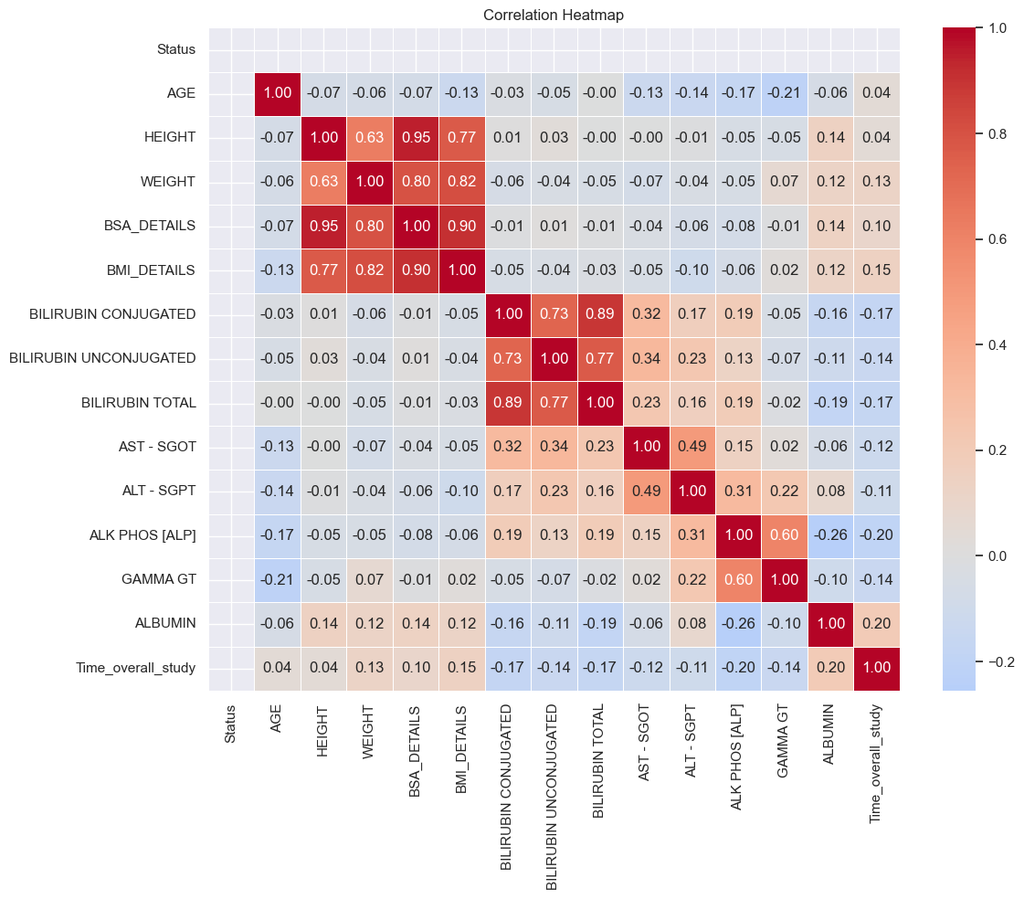

```
Original DataFrame shape: (203, 15)
DataFrame after removing highly correlated variables shape: (203, 13)
```

```python
# Calculate correlation matrix
correlation_matrix = continuous_columns.corr()

# Set up the matplotlib figure
plt.figure(figsize=(12, 10))

# Generate a heatmap
sns.set(font_scale=1)  # Adjust font size for annotations
sns.heatmap(correlation_matrix, annot=True, fmt=".2f", cmap="coolwarm", center=0, linewidths=0.5)

# Add plot title
plt.title("Correlation Heatmap")

# Show the plot
plt.tight_layout()
plt.show()

# Function to remove highly correlated variables
def remove_highly_correlated(continuous_columns, threshold=0.9):
    corr_matrix = continuous_columns.corr().abs()
    upper_tri = corr_matrix.where(np.triu(np.ones(corr_matrix.shape), k=1).astype(np.bool))
    to_drop = [column for column in upper_tri.columns if any(upper_tri[column] > threshold)]
    continuous_columns = continuous_columns.drop(columns=to_drop)
    return continuous_columns

# Remove highly correlated variables
threshold = 0.9
continuous_columns_no_high_correlation = remove_highly_correlated(continuous_columns, threshold)

print("Original DataFrame shape:", continuous_columns.shape)
print("DataFrame after removing highly correlated variables shape:", continuous_columns_no_high_correlation.shape)
```

#### 15 continuous variables were there and now only 13 are left.

```python
##performing one hot encoding to the categorical variables in order to pass the weightage of categorical variables in the form of numbers to our model.
```

```python
# Perform one-hot encoding on categorical columns
encoded_categorical = pd.get_dummies(categorical_columns, drop_first=True)
```

#### Missing value analysis on the final data to be used

```python
print(categorical_columns.isnull().sum())
print("*********************************")
print(continuous_columns_no_high_correlation.isnull().sum())
```

```
Comorbidities_final    0
ECOG_final             0
Gall_stone_final       0
Tumour_stage_final     0
Surgery_final          0
Treatment_final        0
GENDER                 0
Diabetes_final         0
dtype: int64
Status                    0
AGE                       0
HEIGHT                    0
WEIGHT                    0
BILIRUBIN CONJUGATED      0
BILIRUBIN UNCONJUGATED    0
BILIRUBIN TOTAL           0
AST - SGOT                0
ALT - SGPT                0
ALK PHOS [ALP]            0
GAMMA GT                  0
ALBUMIN                   0
Time_overall_study        0
dtype: int64
```

```python
## Taking only 203 observations into the analysis
```

```python
##performing one hot encoding to the categorical variables in order to pass the weightage of categorical variables in the form of numbers to our model.
```

```python
# Concatenate the encoded categorical columns with continuous columns
working_dataframe = pd.concat([encoded_categorical, continuous_columns_no_high_correlation], axis=1)
```

```python
working_dataframe.columns
```

```
Index(['Comorbidities_final_Kidney disease',
       'Comorbidities_final_Lungs disease', 'Comorbidities_final_No',
       'Comorbidities_final_Not known', 'Comorbidities_final_Other cancer',
       'ECOG_final_1', 'ECOG_final_2', 'ECOG_final_3', 'ECOG_final_4',
       'ECOG_final_Not known', 'Gall_stone_final_Not known',
       'Gall_stone_final_Polyp', 'Gall_stone_final_Yes',
       'Tumour_stage_final_Stage II', 'Tumour_stage_final_Stage III',
       'Tumour_stage_final_Stage IV', 'Surgery_final_Partial',
       'Surgery_final_Radical', 'Surgery_final_Simple',
       'Treatment_final_Disease Control', 'Treatment_final_Palliative_care',
       'GENDER_MALE', 'Diabetes_final_Not known', 'Diabetes_final_Yes',
       'Status', 'AGE', 'HEIGHT', 'WEIGHT', 'BILIRUBIN CONJUGATED',
       'BILIRUBIN UNCONJUGATED', 'BILIRUBIN TOTAL', 'AST - SGOT', 'ALT - SGPT',
       'ALK PHOS [ALP]', 'GAMMA GT', 'ALBUMIN', 'Time_overall_study'],
      dtype='object')
```

```python
df = working_dataframe.copy()
```

#### COX ph Model Analysis

```python
from lifelines import CoxPHFitter

cph = CoxPHFitter(alpha=0.05)
cph.fit(df, duration_col='Time_overall_study',
              event_col='Status',
              show_progress = True)
```

```
Iteration 1: norm_delta = 1.20703, step_size = 0.9500, log_lik = -879.15677, newton_decrement = 55.18142, seconds_since_start = 0.0
Iteration 2: norm_delta = 0.56367, step_size = 0.9500, log_lik = -864.41011, newton_decrement = 29.20152, seconds_since_start = 0.0
Iteration 3: norm_delta = 0.10949, step_size = 0.9500, log_lik = -835.30056, newton_decrement = 1.05597, seconds_since_start = 0.0
Iteration 4: norm_delta = 0.02177, step_size = 1.0000, log_lik = -834.13780, newton_decrement = 0.04178, seconds_since_start = 0.0
Iteration 5: norm_delta = 0.00159, step_size = 1.0000, log_lik = -834.09433, newton_decrement = 0.00018, seconds_since_start = 0.0
Iteration 6: norm_delta = 0.00001, step_size = 1.0000, log_lik = -834.09415, newton_decrement = 0.00000, seconds_since_start = 0.0
Convergence success after 6 iterations.
```

```
<lifelines.CoxPHFitter: fitted with 203 total observations, 0 right-censored observations>
```

```python
cph.print_summary(decimals=3)
```

| model | lifelines.CoxPHFitter |
| --- | --- |
| duration col | 'Time_overall_study' |
| event col | 'Status' |
| baseline estimation | breslow |
| number of observations | 203 |
| number of events observed | 203 |
| partial log-likelihood | -834.094 |
| time fit was run | 2023-08-17 12:30:13 UTC |

|  | coef | exp(coef) | se(coef) | coef lower 95% | coef upper 95% | exp(coef) lower 95% | exp(coef) upper 95% | cmp to | z | p | -log2(p) |
| --- | --- | --- | --- | --- | --- | --- | --- | --- | --- | --- | --- |
| Comorbidities_final_Kidney disease | -0.473 | 0.623 | 0.745 | -1.933 | 0.986 | 0.145 | 2.681 | 0.000 | -0.636 | 0.525 | 0.930 |
| Comorbidities_final_Lungs disease | 0.047 | 1.048 | 0.651 | -1.228 | 1.323 | 0.293 | 3.754 | 0.000 | 0.073 | 0.942 | 0.086 |
| Comorbidities_final_No | 0.228 | 1.256 | 0.366 | -0.489 | 0.944 | 0.613 | 2.571 | 0.000 | 0.623 | 0.533 | 0.908 |
| Comorbidities_final_Not known | 0.106 | 1.111 | 0.564 | -0.999 | 1.210 | 0.368 | 3.355 | 0.000 | 0.188 | 0.851 | 0.232 |
| Comorbidities_final_Other cancer | 0.765 | 2.148 | 0.732 | -0.669 | 2.199 | 0.512 | 9.012 | 0.000 | 1.045 | 0.296 | 1.757 |
| ECOG_final_1 | -0.849 | 0.428 | 0.385 | -1.603 | -0.095 | 0.201 | 0.909 | 0.000 | -2.208 | 0.027 | 5.198 |
| ECOG_final_2 | -0.701 | 0.496 | 0.394 | -1.474 | 0.072 | 0.229 | 1.074 | 0.000 | -1.778 | 0.075 | 3.731 |
| ECOG_final_3 | -0.340 | 0.711 | 0.564 | -1.446 | 0.765 | 0.236 | 2.149 | 0.000 | -0.604 | 0.546 | 0.873 |
| ECOG_final_4 | -0.195 | 0.823 | 0.931 | -2.021 | 1.631 | 0.133 | 5.107 | 0.000 | -0.209 | 0.834 | 0.262 |
| ECOG_final_Not known | 0.121 | 1.129 | 0.810 | -1.467 | 1.710 | 0.231 | 5.527 | 0.000 | 0.150 | 0.881 | 0.183 |
| Gall_stone_final_Not known | 0.393 | 1.481 | 0.234 | -0.067 | 0.852 | 0.936 | 2.345 | 0.000 | 1.676 | 0.094 | 3.416 |
| Gall_stone_final_Polyp | -1.362 | 0.256 | 1.151 | -3.617 | 0.894 | 0.027 | 2.444 | 0.000 | -1.183 | 0.237 | 2.079 |
| Gall_stone_final_Yes | 0.499 | 1.647 | 0.212 | 0.084 | 0.914 | 1.088 | 2.494 | 0.000 | 2.359 | 0.018 | 5.771 |
| Tumour_stage_final_Stage II | -0.138 | 0.871 | 0.565 | -1.246 | 0.970 | 0.288 | 2.637 | 0.000 | -0.244 | 0.807 | 0.310 |
| Tumour_stage_final_Stage III | -0.178 | 0.837 | 0.421 | -1.003 | 0.648 | 0.367 | 1.911 | 0.000 | -0.422 | 0.673 | 0.571 |
| Tumour_stage_final_Stage IV | -0.549 | 0.577 | 0.346 | -1.228 | 0.129 | 0.293 | 1.138 | 0.000 | -1.586 | 0.113 | 3.150 |
| Surgery_final_Partial | -0.851 | 0.427 | 0.645 | -2.116 | 0.413 | 0.121 | 1.512 | 0.000 | -1.319 | 0.187 | 2.418 |
| Surgery_final_Radical | -0.561 | 0.571 | 0.463 | -1.468 | 0.346 | 0.230 | 1.414 | 0.000 | -1.212 | 0.226 | 2.149 |
| Surgery_final_Simple | -0.360 | 0.697 | 0.207 | -0.766 | 0.045 | 0.465 | 1.046 | 0.000 | -1.742 | 0.081 | 3.618 |
| Treatment_final_Disease Control | -0.467 | 0.627 | 0.535 | -1.515 | 0.582 | 0.220 | 1.789 | 0.000 | -0.873 | 0.383 | 1.385 |
| Treatment_final_Palliative_care | 0.356 | 1.428 | 0.595 | -0.810 | 1.523 | 0.445 | 4.586 | 0.000 | 0.599 | 0.549 | 0.864 |
| GENDER_MALE | 0.038 | 1.039 | 0.197 | -0.348 | 0.424 | 0.706 | 1.528 | 0.000 | 0.193 | 0.847 | 0.239 |
| Diabetes_final_Not known | 0.237 | 1.268 | 0.520 | -0.782 | 1.257 | 0.458 | 3.513 | 0.000 | 0.457 | 0.648 | 0.626 |
| Diabetes_final_Yes | 0.211 | 1.235 | 0.193 | -0.167 | 0.590 | 0.846 | 1.803 | 0.000 | 1.096 | 0.273 | 1.872 |
| AGE | -0.003 | 0.997 | 0.009 | -0.021 | 0.015 | 0.980 | 1.015 | 0.000 | -0.308 | 0.758 | 0.400 |
| HEIGHT | 0.003 | 1.003 | 0.003 | -0.004 | 0.009 | 0.996 | 1.009 | 0.000 | 0.852 | 0.394 | 1.342 |
| WEIGHT | -0.010 | 0.990 | 0.007 | -0.025 | 0.004 | 0.975 | 1.004 | 0.000 | -1.383 | 0.167 | 2.585 |
| BILIRUBIN CONJUGATED | 0.124 | 1.132 | 0.052 | 0.023 | 0.225 | 1.023 | 1.253 | 0.000 | 2.410 | 0.016 | 5.972 |
| BILIRUBIN UNCONJUGATED | -0.341 | 0.711 | 0.246 | -0.824 | 0.142 | 0.439 | 1.153 | 0.000 | -1.384 | 0.166 | 2.587 |
| BILIRUBIN TOTAL | 0.010 | 1.010 | 0.028 | -0.045 | 0.064 | 0.956 | 1.066 | 0.000 | 0.350 | 0.726 | 0.461 |
| AST - SGOT | 0.000 | 1.000 | 0.001 | -0.001 | 0.001 | 0.999 | 1.001 | 0.000 | 0.601 | 0.548 | 0.868 |
| ALT - SGPT | -0.001 | 0.999 | 0.001 | -0.003 | 0.002 | 0.997 | 1.002 | 0.000 | -0.500 | 0.617 | 0.697 |
| ALK PHOS [ALP] | 0.000 | 1.000 | 0.000 | -0.000 | 0.001 | 1.000 | 1.001 | 0.000 | 1.332 | 0.183 | 2.452 |
| GAMMA GT | 0.000 | 1.000 | 0.000 | -0.000 | 0.001 | 1.000 | 1.001 | 0.000 | 0.956 | 0.339 | 1.560 |
| ALBUMIN | -0.339 | 0.713 | 0.144 | -0.621 | -0.056 | 0.538 | 0.945 | 0.000 | -2.351 | 0.019 | 5.741 |

| Concordance | 0.685 |
| --- | --- |
| Partial AIC | 1738.188 |
| log-likelihood ratio test | 90.125 on 35 df |
| -log2(p) of ll-ratio test | 20.015 |

### The variables taken into the cox ph model does not show any significance on the disease since no variable has p-value<0.005, which is actually not possible. Therefore for actual analysis we need to have the knowledge of variables that must be taken into the analysis and rest all the variables must be dropped and cohort must be chosen under the knowledge of the domain expert.